# GitDemo

This is a demonstration script to show how a script can be converted to an R project and then a Git repository to be shared.

## Why git??

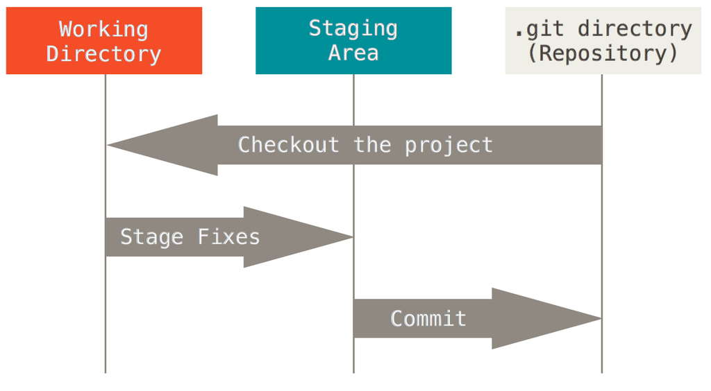

**Version control!**

This approach improves security and reproducibility.

More information and background: https://r-bio.github.io/intro-git-rstudio/

## Setting up Git on your computer

### Step Zero

Install git and create a github profile online.

```r
system2(command = 'git', stdout = TRUE)
```

```
##  [1] "usage: git [--version] [--help] [-C <path>] [-c <name>=<value>]"
##  [2] "           [--exec-path[=<path>]] [--html-path] [--man-path] [--info-path]"
##  [3] "           [-p | --paginate | -P | --no-pager] [--no-replace-objects] [--bare]"
##  [4] "           [--git-dir=<path>] [--work-tree=<path>] [--namespace=<name>]"
##  [5] "           [--super-prefix=<path>] [--config-env=<name>=<envvar>]"
##  [6] "           <command> [<args>]"
##  [7] ""
##  [8] "These are common Git commands used in various situations:"
##  [9] ""
## [10] "start a working area (see also: git help tutorial)"
## [11] "   clone     Clone a repository into a new directory"
## [12] "   init      Create an empty Git repository or reinitialize an existing one"
## [13] ""
## [14] "work on the current change (see also: git help everyday)"
## [15] "   add       Add file contents to the index"
```

[output cut: 32 more lines]

If your computer doesn’t have git installed, this command should prompt an install.

After that, you can set up the connection to your github profile

```r
install.packages("usethis")
use_git_config(user.name = "Jane Doe", user.email = "jane@example.com")
# fill in your github username and associated email above
git_vaccinate()
create_github_token()
gitcreds::gitcreds_set()
```

Then we are set to load the library and get a status report

```r
library(usethis)
usethis::git_sitrep()
```

```
## Git config (global)
## * Name: 'gghill'
## * Email: 'gghill@alumni.stanford.edu'
## * Global (user-level) gitignore file: 'C:/Users/06108182/.gitignore'
## * Vaccinated: TRUE
## i Defaulting to 'https' Git protocol
## * Default Git protocol: 'https'
## * Default initial branch name: 'master'
## GitHub
## * Default GitHub host: 'https://github.com'
## * Personal access token for 'https://github.com': '<discovered>'
## * GitHub user: 'gghill'
## * Token scopes: 'delete_repo, gist, repo, user, workflow'
## * Email(s): 'gghill@alumni.stanford.edu (primary)', '72388589+gghill@users.noreply.github.com'
## Git repo for current project
## * Active usethis project: 'C:/Users/06108182/OneDrive - Nord universitet/Analysis/GitDemo'
## * Default branch: 'main'
## * Current local branch -> remote tracking branch:
##   'main' -> 'origin/main'
## GitHub remote configuration
## * Type = 'ours'
## * Host = 'https://github.com'
## * Config supports a pull request = TRUE
## * origin = 'gghill/GitDemo' (can push)
## * upstream = <not configured>
## * Desc = 'origin' is both the source and primary repo.
##
##   Read more about the GitHub remote configurations that usethis supports at:
##   'https://happygitwithr.com/common-remote-setups.html'
```

## Getting your code ready for github

### Create an R project

This is a useful structure to organize multiple scripts within a project on its own, but is also the base unit of a git repository.

[figure not shown]

File > New Project > Existing Directory

Or via command line:

```r
create_project(path = "../GitDemo", open = TRUE, rstudio = TRUE)
```

### Initialize git

Then all that is left to do is initialize git while in our directory with the R project.

```r
system2(command = "git init", stdout = TRUE)
```

Restart R Studio, if it worked you should have a .Rproj file in your directory and a Git tab in R Studio.

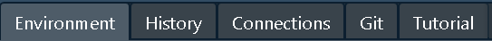

Next we **commit**, but don’t push! This can be done via command line (below, for reference), but I always do it manually.

```r
system2(command = "git add .", stdout = TRUE)
system2(command = 'git commit -m "Initial commit"', stdout = TRUE)
```

Now we move to setting up the github side, creating a new repo and using the presets for an existing directory.

https://github.com/gghill

github will give us some code which we need to run in the terminal *not* console

```
git remote add origin https://github.com/YOURUSERNAME/example_project.git
git branch -M main
git push -u origin main
```

## Done!

Now you can code, commit, and push to keep an online version up to date and visible to collaborators.

Other functions:

- README
- gitignore
- Fork
- Branch
  - model development
- Pull
- Organizations!

https://github.com/gghill/GitDemo

Additional reading on the workflow:

https://medium.com/@jonathanmines/the-ultimate-github-collaboration-guide-df816e98fb67